*N* removed NAs: 2

*N* removed typo: 1

*N* removed <18: 29

*N* total clean: 118

| Group | *N* | *M*<sub>age</sub> | *M*<sub>rating</sub> |
| --- | --- | --- | --- |
| Control | 60 | 20.88 | 6.29 |
| Experim | 58 | 20.81 | 5.15 |

**Main analysis results**

*t*(116) = 7.56, *p* < .001

[interactive chart not shown]

[figure not shown]

[interactive chart not shown]

# Methods

## Participants

150 people originally participated in this experiment to see if colour influences attraction. 32 participants were removed due to the unethical ages and incorrect information. So the final number of participants whose data was included was 118. The mean, standard deviation and range of ages is demonstrated in Table1 and Table2.

Table1 Descriptive statistics by age.

| Mean age | SD age | Min age | Max age |
| --- | --- | --- | --- |
| 20.85 | 1.93 | 18 | 28 |

Table2 Descriptive statistics by age for each condition (Control - white and Experimental - red).

| Condition | Mean age | SD age | Min age | Max age |
| --- | --- | --- | --- | --- |
| Control | 20.88 | 1.99 | 18 | 28 |
| Experimental | 20.81 | 1.89 | 18 | 26 |

## Design

The aim of this experiment was to see if the colour red increases women’s attraction to men in relation to the man’s status. The hypothesis is that the colour red does make men seem more attractive to women. This was tested by participants looking at one of two pictures in a frame, the colour of these frames was the independent categorical variable. The control condition had a white frame and the experimental condition had a red frame. The man in the picture was rated on attractiveness which is the continuous variable. The ratings were measured on a 1-9 scale for three questions, where 1 was not attractive and 9 very attractive. The three questions were, how attractive do you think the person is? How pleasant is the person to look at? and If I were to meet the person in the picture face to face, would I think he was attractive. The answers to these questions were averaged to get a composite score which will be used to complete a *t*-test.

# Results

Table3 Composite score for each condition.

| Condition | Composite mean |
| --- | --- |
| Control | 6.29 |
| Experimental | 5.15 |

Graph1 Composite sore for each condition, control (white frame) and experimental (red frame).

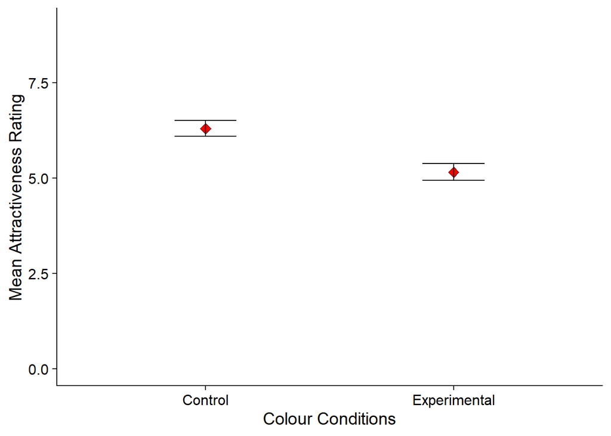

# Discussion

The main finding of this analysis is that red did not make men more attractive to women as the white framed control condition scored higher in attractiveness on the combined three scores. This contradicts the original study which did find that red frames made men more attractive to women (Elliot et al., 2010). However, this wasn’t found in other studies with the same hypothesis, Peperkoorn et al. (2016) study failed to support that just the colour red by itself improves men’s attractiveness to women. In one of the experiments they found no significant difference in attractiveness rating of women dressed in red versus white. This finding is also supported by Lynn et al. (2016). A limiation of my replication is that some of the data had to be cleaned and therefore we lost some participants making the sample smaller. This could have affected the results as we had ended up with a less diverse sample. Another limitation is that we did not conduct an analysis to find out why the white control condition scored higher than the expected red experimental condition, further statistical testing could have been used. These findings along with the results and limitations of this analysis show that further research needs to be conducted in this area to see if there is an underlying factor that hasn’t been discovered that contributes to the attractiveness of men in conjunction with the colour red.

An idea for further research could be, using not just self-report questionnaires but physical bodily reactions for example sweat production and pupil dilatation. Other research could be conducted to see if the same effects of the original study (Elliot et al., 2010) are present when different red objects are present like clothing or blushing. This may still produce the result that red does make men more attractive to women as female primates have a good detection and interpretation of blood flow to the face of males (Changizi et al., 2006). Another area to expand is if the colour red and attractiveness ratings are effected by the menstrual cycle, this has started to be researched and findings show that in female vertebrates sensitivity to red increases when the likelihood of conception is highest (Boulcott & Braith, 2007; Cronly-Dillon & Sharma, 1968). This could be researched to see if the same effects are found in humans. Further research could be conducted to see if the colour red effects sexual attraction, Wen et al. (2014) hinted at a prediction that women in red are more sexually attractive in red than white clothing. However, this is only an idea and needs to be tested further.

Due to collective finding’s, red does make men more attractive to females, especially in terms of other non-human animals. Waitt et al. (2003) found red to be more attractive to female rhesus monkeys. They showed females computer images of male faces which had been either changed to be redder in colour or paler. This is because male rhesus macaque’s face and anogenital areas increase in red colouration during mating season due to hormonal changes. They measured preference by duration and direction of the female’s gaze, and they found that females had a higher preference for males with a redder face. However, for humans this hypothesis that red makes men more attractive to women may be too simple, demonstrated by my own analysis contradicting it and other research. Therefore other factors may contribute for example partner preferences of women have been found to be good financial prospects and intelligence (Buss, 1989).

In conclusion, further study needs to be conducted into this topic before a definitive hypothesis can be reached.

# References

Boulcott, P., & Braithwaite, V. A. (2007). Color perception in three-spined sticklebacks: Sexes are not so different after all. *Evolutionary Ecology, 21,* 601–611.

Buss, D.M. (1989). Sex differences in human mate preferences: Evolutionary hypotheses tested in 37 cultures. *Behavioural and Brain Sciences, 12,* 1-49.

Changizi, M. A., Zhang, Q., & Shimojo, S. (2006). Bare skin, blood, and the evolution of primate colour vision. *Biology Letters, 2,* 217–221.

Cronly-Dillon, J., & Sharma, S. C. (1968). Effect of season and sex on the photopic spectral sensitivity of the three-spined stickleback. *Journal of Experimental Biology, 49,* 679–687.

Elliot, A. J., Niesta Kayser, D., Greitemeyer, T., Lichtenfeld, S., Gramzow, R. H., Maier, M. A., & Liu, H. (2010). Red, rank, and romance in women viewing men. *Journal of Experimental Psychology: General, 139*(3), 399.

Peperkoorn, Leonard S., S. Craig Roberts, and Thomas V. Pollet. ‘(17 October 2016): Revisiting the Red Effect on Attractiveness and Sexual Receptivity: No Effect of the Color Red on Human Mate Preferences’. *Evolutionary Psychology 14,*no. 4:147470491667384. https://doi.org/10.1177/1474704916673841.

Lynn, M., Giebelhausen, M., Garcia, S., Li, Y., Patumanon, I. (2016). Clothing color and tipping: An attempted replication and extension. *Journal of Hospitialty & Tourism Research, 40* ,516-524.

Waitt, C., Little, A., Wolfensohn, S., Honess, P., Brown, A., Buchanan-Smith, H., & Perrett, D. (2003). Evidence from rhesus macaques suggests that male coloration plays a role in female primate mate choice. *Proceedings of The Royal Society of London. Series B: Biological Sciences, 270*.doi: 10.1098/rsbl.2003.0065.

Wen, F., Zuo, B., Wu, Y., Sun, S., Liu, K.(2014). Red is romantic, but only for feminine females: Sexual dimorphism moderates red effect on sexual attraction. *Evolutionary Psychology,12,* 719-735.